# Data Exploration with a categorical response variable (HRA Data)

Yin-Ting

2017-01-26

### Overview

This post is about how I do data exploration when response variable is categorical and explanotary variables are both continuous and categorical. I used HRA Data as an example to show how to do it in R. In the beginning, I summarize a general idea about doing data exploration. Then, I will show how to do data cleaning and then create an efficient function to create tables and graphs at one time using HRA Data as an example.

### Details

* **General Ideas**  
When we are doing data exploration, generally, there are two things we are interested in:  
1. the relationship **between the response variable and all the other explanatory variables**. 2. the relationship **between all the explanatory variables**.

And, the relationship here can be shown by using tables or graphs which can give us enough insights of data before we start to do modeling.

| **Variables** | **Numerical** | **Categorical** |
| --- | --- | --- |
| **Numerical** | Correlation Coefficient Scatter Plot | Summary Table Side by Side Box Plot Overlapping Histograms |
| —— |  |  |
| **Categorical** | Summary Table Side by Side Box Plot Overlapping Histograms | Contingency Table |
| ——- |  |  |

* **Data Cleaning**  
Before doing data exploration, we need to make sure that the data is clean and ready to be used.

```r ############################ #### 1. Import Raw Data #### ############################ dat=read.csv(“https://choux130.github.io/myblog/DATA/HR_analytics.csv”, header=TRUE) data=dat # keep raw data pure

################################# #### 2. Rename the variables #### ################################# names(data)=c(“satisf_level”,“last_eval”,“num_proj”, “ave_mon_hrs”,“time_spend”,“work_accid”, “left_or_not”,“promo_last_5yrs”,“department”, “salary”)

############################# #### 3. Reorder the data #### ############################# data=data[,c(1:6,8:10,7)]

##################################### #### 4. Correct variables’ types #### ##################################### data[,c(“work_accid”,“promo_last_5yrs”,“left_or_not”)]= lapply(data[,c(“work_accid”,“promo_last_5yrs”,“left_or_not”)],as.factor) str(data) ```

`## 'data.frame': 14999 obs. of 10 variables: ## $ satisf_level : num 0.38 0.8 0.11 0.72 0.37 0.41 0.1 0.92 0.89 0.42 ... ## $ last_eval : num 0.53 0.86 0.88 0.87 0.52 0.5 0.77 0.85 1 0.53 ... ## $ num_proj : int 2 5 7 5 2 2 6 5 5 2 ... ## $ ave_mon_hrs : int 157 262 272 223 159 153 247 259 224 142 ... ## $ time_spend : int 3 6 4 5 3 3 4 5 5 3 ... ## $ work_accid : Factor w/ 2 levels "0","1": 1 1 1 1 1 1 1 1 1 1 ... ## $ promo_last_5yrs: Factor w/ 2 levels "0","1": 1 1 1 1 1 1 1 1 1 1 ... ## $ department : Factor w/ 10 levels "accounting","hr",..: 8 8 8 8 8 8 8 8 8 8 ... ## $ salary : Factor w/ 3 levels "high","low","medium": 2 3 3 2 2 2 2 2 2 2 ... ## $ left_or_not : Factor w/ 2 levels "0","1": 2 2 2 2 2 2 2 2 2 2 ...`

`r ####################### #### 5. Finding NA #### ####################### which(is.na(data), arr.ind=TRUE) #the indices of NA values`

`## row col`  
### Self-defined R functions

- **Categorical Response Variables vs. Numeric Explanotary Variables**
- **Variables:**
  - Response Variables :
  - Whether the employee has left — *(0=“leave”, 1=“not leave”)*
  - Numeric Explanotary Variables:
  - Employee satisfaction level — *(between 0 and 1)*
  - Last evaluation — *(between 0 and 1)*
  - Number of projects — *(integer)*
  - Average monthly hours — *(integer)*
  - Time spent at the company — *(integer)*
- **Introduction**  
  The self-defined function, `all_bygroup()` which can show Summary Table, Overlapping Histograms and Side by side Box plot.

```r ################################ #### Summary Table by group ### ############################### t_bygroup=function(d, xx, yy, round){ # an elegant way to install a missing package if (!require(“plyr”)) install.packages(“plyr”) t <- ddply(d, yy, .fun = function(dd){ c(Mean = round(mean(dd[,xx],na.rm=TRUE),round), Sd = round(sd(dd[,xx],na.rm=TRUE),round), min=round(min(dd[,xx]),round), Q1=round(quantile(dd[,xx],0.25),round), Q2=round(quantile(dd[,xx],0.5),round), Q3=round(quantile(dd[,xx],0.75),round), Max=round(max(dd[,xx]),round)) }) return(t) }

######################################### #### Overlapping Histograms by group #### ######################################### hist_bygroup=function(d,xx,yy,name){ if (!require(“ggplot2”)) install.packages(“ggplot2”) ggplot(d, aes_string(x=xx, color=yy, fill=yy)) + geom_histogram(aes(y=..density..), alpha=0.5, position=“identity”) + geom_density(alpha=.3)+ ggtitle(name)  
}

####################################### #### Side by side boxplot by group #### ####################################### box_bygroup=function(d,xx,yy,name){ if (!require(“ggplot2”)) install.packages(“ggplot2”) ggplot(d, aes_string(x=yy, y=xx, fill=yy)) + geom_boxplot() + ggtitle(name) }

###################################################### #### Function for summary table, hist and boxplot #### ###################################################### all_bygroup=function(d, xx, yy, round){ if (!require(“grid”)) install.packages(“grid”) if (!require(“gridExtra”)) install.packages(“gridExtra”) if (!require(“gtable”)) install.packages(“gtable”) #the summary table t=t_bygroup(d=d, xx, yy, round) tt = tableGrob(data.frame(t)) title <- textGrob(paste(xx,“by”,yy),gp=gpar(fontsize=15)) table <- gtable_add_rows( tt, heights = grobHeight(title) + unit(5,“mm”), pos = 0) # http://www.itkeyword.com/doc/2912033176253512950/how-can-i-add-a-title-to-a-tablegrob-plot table <- gtable_add_grob( table, title, 1, 1, 1, ncol(table))

#the histogram hist=hist_bygroup(d=data, xx, yy, paste(“Histogram for”, xx, “by”, yy))

#the boxplot box=box_bygroup(d=data, xx, yy, paste(“Boxplot for”, xx, “by”, yy))

#grid.arrange(hist,box, nrow=1) #grid.arrange(tableGrob(data.frame(t))) #make the output table become a plot grid.arrange(hist,box,table, layout_matrix = rbind(c(1,2),c(3,3)), heights = c(2,1)) #make the output table become a plot } ```

- **Draw it out at one time**  
  By using `lapply()`, I can do `all_bygroup()` on all the numeric variables.

```r # list all the numeric explanatory variables vars_num=c(“satisf_level”, “last_eval”, “num_proj”, “ave_mon_hrs”, “time_spend”)

# the response variable y=“left_or_not”

#the invisible() here is to hide the unwanted output from lapply invisible(lapply(vars_num, all_bygroup, d=data, yy=y, round=2)) ```

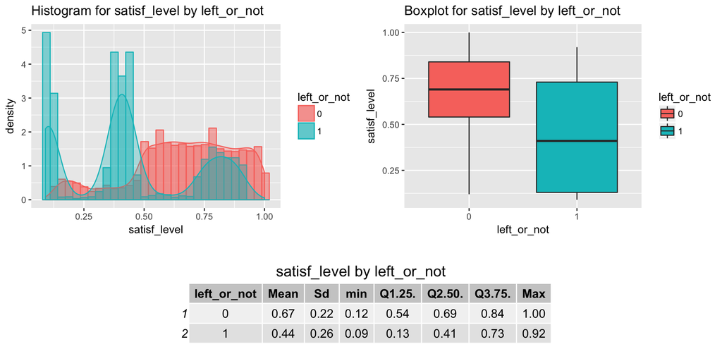

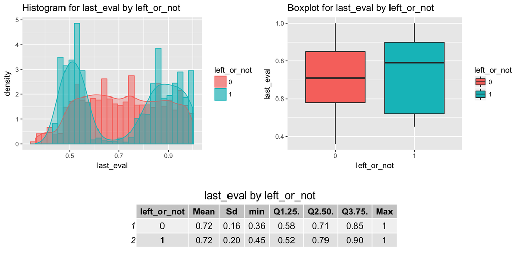

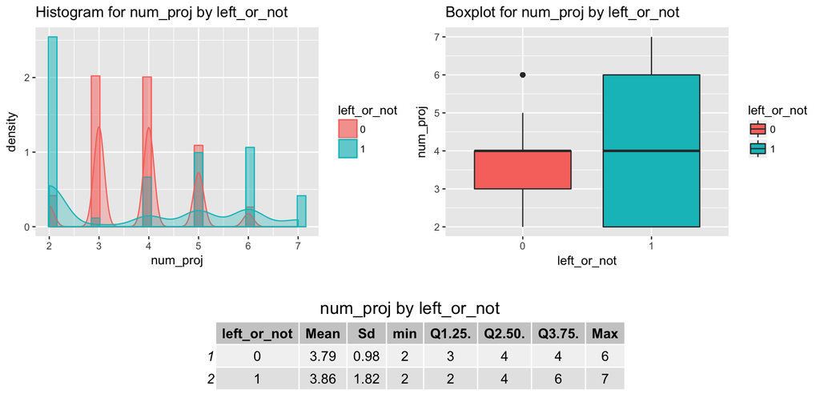

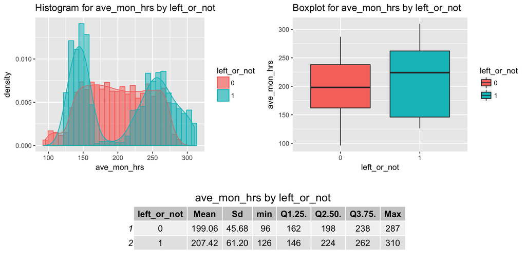

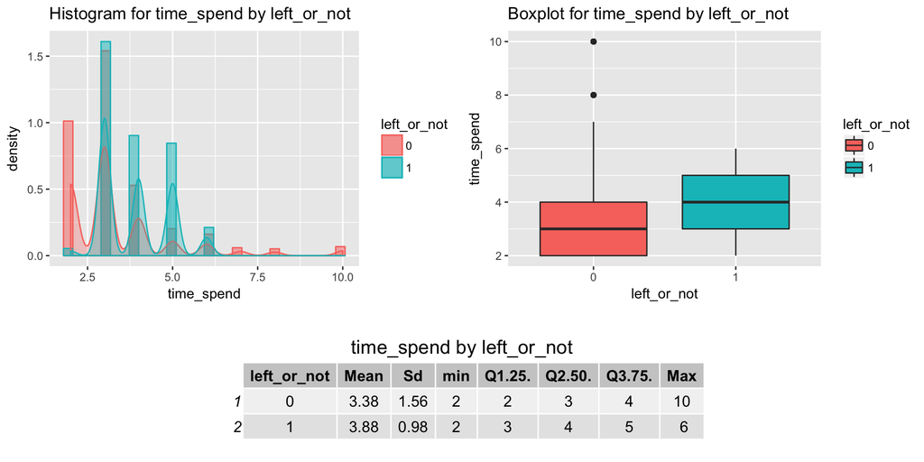

* **Categorical Response Variables vs. Categorical Explanotary Variables** * **Variables:** + Response Variables :  
- Whether the employee has left — *(0=“leave”, 1=“not leave”)*  
+ Categorical Explanotary Variables:  
- Whether they have had a work accident — *(0=“No”, 1=“Yes”)*  
- Whether they have had a promotion in the last 5 years — *(0=“No”, 1=“Yes”)* - Department —  
*(“accounting”, “hr”, “IT”, “management”, “marketing”, “product_mng”, “RandD”, “sales”, “support”, “technical”)*  
- Salary — *(“high”, “medium”, “low”)* * **Introduction**  
The self-defined function, `tab_bygroup()` which can show two-way table similar to tables in SPSS.

`r tab_bygroup=function(d, xx, yy, digits, prop.r, prop.c, prop.chisq){ if (!require("gmodels")) install.packages("gmodels") CrossTable(x=d[[xx]], y=d[[yy]], digitd=digits, prop.r=prop.r, prop.c=prop.c, prop.chisq=prop.chisq, format=c("SPSS"), dnn=c(xx,yy)) }`

- **Generate tables at one time**  
  By using `lapply()`, I can do `tab_bygroup()` on all the categorical variables.

`r vars_cat=c("work_accid", "promo_last_5yrs", "department", "salary") invisible(lapply(vars_cat, tab_bygroup, d=data, yy="left_or_not", digits=3, prop.r=TRUE, prop.c=TRUE, prop.chisq=FALSE))`

`## ## Cell Contents ## |-------------------------| ## | Count | ## | Row Percent | ## | Column Percent | ## | Total Percent | ## |-------------------------| ## ## Total Observations in Table: 14999 ## ## | left_or_not ## work_accid | 0 | 1 | Row Total | ## -------------|-----------|-----------|-----------| ## 0 | 9428 | 3402 | 12830 | ## | 73.484% | 26.516% | 85.539% | ## | 82.499% | 95.267% | | ## | 62.858% | 22.682% | | ## -------------|-----------|-----------|-----------| ## 1 | 2000 | 169 | 2169 | ## | 92.208% | 7.792% | 14.461% | ## | 17.501% | 4.733% | | ## | 13.334% | 1.127% | | ## -------------|-----------|-----------|-----------| ## Column Total | 11428 | 3571 | 14999 | ## | 76.192% | 23.808% | | ## -------------|-----------|-----------|-----------| ## ## ## ## Cell Contents ## |-------------------------| ## | Count | ## | Row Percent | ## | Column Percent | ## | Total Percent | ## |-------------------------| ## ## Total Observations in Table: 14999 ## ## | left_or_not ## promo_last_5yrs | 0 | 1 | Row Total | ## ----------------|-----------|-----------|-----------| ## 0 | 11128 | 3552 | 14680 | ## | 75.804% | 24.196% | 97.873% | ## | 97.375% | 99.468% | | ## | 74.192% | 23.682% | | ## ----------------|-----------|-----------|-----------| ## 1 | 300 | 19 | 319 | ## | 94.044% | 5.956% | 2.127% | ## | 2.625% | 0.532% | | ## | 2.000% | 0.127% | | ## ----------------|-----------|-----------|-----------| ## Column Total | 11428 | 3571 | 14999 | ## | 76.192% | 23.808% | | ## ----------------|-----------|-----------|-----------| ## ## ## ## Cell Contents ## |-------------------------| ## | Count | ## | Row Percent | ## | Column Percent | ## | Total Percent | ## |-------------------------| ## ## Total Observations in Table: 14999 ## ## | left_or_not ## department | 0 | 1 | Row Total | ## -------------|-----------|-----------|-----------| ## accounting | 563 | 204 | 767 | ## | 73.403% | 26.597% | 5.114% | ## | 4.926% | 5.713% | | ## | 3.754% | 1.360% | | ## -------------|-----------|-----------|-----------| ## hr | 524 | 215 | 739 | ## | 70.907% | 29.093% | 4.927% | ## | 4.585% | 6.021% | | ## | 3.494% | 1.433% | | ## -------------|-----------|-----------|-----------| ## IT | 954 | 273 | 1227 | ## | 77.751% | 22.249% | 8.181% | ## | 8.348% | 7.645% | | ## | 6.360% | 1.820% | | ## -------------|-----------|-----------|-----------| ## management | 539 | 91 | 630 | ## | 85.556% | 14.444% | 4.200% | ## | 4.716% | 2.548% | | ## | 3.594% | 0.607% | | ## -------------|-----------|-----------|-----------| ## marketing | 655 | 203 | 858 | ## | 76.340% | 23.660% | 5.720% | ## | 5.732% | 5.685% | | ## | 4.367% | 1.353% | | ## -------------|-----------|-----------|-----------| ## product_mng | 704 | 198 | 902 | ## | 78.049% | 21.951% | 6.014% | ## | 6.160% | 5.545% | | ## | 4.694% | 1.320% | | ## -------------|-----------|-----------|-----------| ## RandD | 666 | 121 | 787 | ## | 84.625% | 15.375% | 5.247% | ## | 5.828% | 3.388% | | ## | 4.440% | 0.807% | | ## -------------|-----------|-----------|-----------| ## sales | 3126 | 1014 | 4140 | ## | 75.507% | 24.493% | 27.602% | ## | 27.354% | 28.395% | | ## | 20.841% | 6.760% | | ## -------------|-----------|-----------|-----------| ## support | 1674 | 555 | 2229 | ## | 75.101% | 24.899% | 14.861% | ## | 14.648% | 15.542% | | ## | 11.161% | 3.700% | | ## -------------|-----------|-----------|-----------| ## technical | 2023 | 697 | 2720 | ## | 74.375% | 25.625% | 18.135% | ## | 17.702% | 19.518% | | ## | 13.488% | 4.647% | | ## -------------|-----------|-----------|-----------| ## Column Total | 11428 | 3571 | 14999 | ## | 76.192% | 23.808% | | ## -------------|-----------|-----------|-----------| ## ## ## ## Cell Contents ## |-------------------------| ## | Count | ## | Row Percent | ## | Column Percent | ## | Total Percent | ## |-------------------------| ## ## Total Observations in Table: 14999 ## ## | left_or_not ## salary | 0 | 1 | Row Total | ## -------------|-----------|-----------|-----------| ## high | 1155 | 82 | 1237 | ## | 93.371% | 6.629% | 8.247% | ## | 10.107% | 2.296% | | ## | 7.701% | 0.547% | | ## -------------|-----------|-----------|-----------| ## low | 5144 | 2172 | 7316 | ## | 70.312% | 29.688% | 48.777% | ## | 45.012% | 60.823% | | ## | 34.296% | 14.481% | | ## -------------|-----------|-----------|-----------| ## medium | 5129 | 1317 | 6446 | ## | 79.569% | 20.431% | 42.976% | ## | 44.881% | 36.880% | | ## | 34.196% | 8.781% | | ## -------------|-----------|-----------|-----------| ## Column Total | 11428 | 3571 | 14999 | ## | 76.192% | 23.808% | | ## -------------|-----------|-----------|-----------| ## ##`  
* **Between Numeric Explanotary Variables** * **Introduction**  
By using the `ggpairs()` function in `GGally` package, I can draw a scatter matrix with correlation coefficient and overlapping historgrams for all the numeric variables. * **Draw it out at one time**

`r if (!require("GGally")) install.packages("GGally") ggpairs(data=data, columns = c(1:5), mapping=ggplot2::aes(colour = left_or_not, alpha=0.9))`

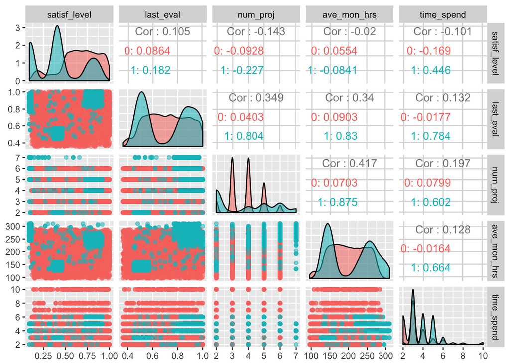

* **Between Categorical Explanotary Variables** * **Introduction**  
In addition to using the function, `CrossTable()`, to generate contingency table, we also can flexibly use `xtabs()`, `combn()` and `mapply()` to create many contingency tables at one time. * **Generate tables at one time**

```r ###################################### #### Contingency table with count #### ###################################### tab=function(xx,yy,df){ formula <- as.formula(paste(“~”, xx, “+”, yy)) xtabs(data=df, formula) }

# list all the combination of two categorical variables tt=t(combn(c(“work_accid”,“promo_last_5yrs”, “department”,“salary”),2))

# apply the function to all the combinations tab_count=mapply(tab, tt[,1], tt[,2], list(data))  
names(tab_count) = c(1:length(tab_count))

# sum of marginals tab_sum=lapply(tab_count,addmargins) print(tab_sum) ```

`` ## $`1` ## promo_last_5yrs ## work_accid 0 1 Sum ## 0 12587 243 12830 ## 1 2093 76 2169 ## Sum 14680 319 14999 ## ## $`2` ## department ## work_accid accounting hr IT management marketing product_mng RandD ## 0 671 650 1063 527 720 770 653 ## 1 96 89 164 103 138 132 134 ## Sum 767 739 1227 630 858 902 787 ## department ## work_accid sales support technical Sum ## 0 3553 1884 2339 12830 ## 1 587 345 381 2169 ## Sum 4140 2229 2720 14999 ## ## $`3` ## salary ## work_accid high low medium Sum ## 0 1045 6276 5509 12830 ## 1 192 1040 937 2169 ## Sum 1237 7316 6446 14999 ## ## $`4` ## department ## promo_last_5yrs accounting hr IT management marketing product_mng ## 0 753 724 1224 561 815 902 ## 1 14 15 3 69 43 0 ## Sum 767 739 1227 630 858 902 ## department ## promo_last_5yrs RandD sales support technical Sum ## 0 760 4040 2209 2692 14680 ## 1 27 100 20 28 319 ## Sum 787 4140 2229 2720 14999 ## ## $`5` ## salary ## promo_last_5yrs high low medium Sum ## 0 1165 7250 6265 14680 ## 1 72 66 181 319 ## Sum 1237 7316 6446 14999 ## ## $`6` ## salary ## department high low medium Sum ## accounting 74 358 335 767 ## hr 45 335 359 739 ## IT 83 609 535 1227 ## management 225 180 225 630 ## marketing 80 402 376 858 ## product_mng 68 451 383 902 ## RandD 51 364 372 787 ## sales 269 2099 1772 4140 ## support 141 1146 942 2229 ## technical 201 1372 1147 2720 ## Sum 1237 7316 6446 14999 ``

`r ########################################### #### Contingency table with percentage #### ########################################### if (!require("magrittr")) install.packages("magrittr") tab_count %>% lapply(., prop.table) %>% lapply(., addmargins) %>% lapply(., round, 3) ->tab_prop_sum print(tab_prop_sum)`

`` ## $`1` ## promo_last_5yrs ## work_accid 0 1 Sum ## 0 0.839 0.016 0.855 ## 1 0.140 0.005 0.145 ## Sum 0.979 0.021 1.000 ## ## $`2` ## department ## work_accid accounting hr IT management marketing product_mng RandD ## 0 0.045 0.043 0.071 0.035 0.048 0.051 0.044 ## 1 0.006 0.006 0.011 0.007 0.009 0.009 0.009 ## Sum 0.051 0.049 0.082 0.042 0.057 0.060 0.052 ## department ## work_accid sales support technical Sum ## 0 0.237 0.126 0.156 0.855 ## 1 0.039 0.023 0.025 0.145 ## Sum 0.276 0.149 0.181 1.000 ## ## $`3` ## salary ## work_accid high low medium Sum ## 0 0.070 0.418 0.367 0.855 ## 1 0.013 0.069 0.062 0.145 ## Sum 0.082 0.488 0.430 1.000 ## ## $`4` ## department ## promo_last_5yrs accounting hr IT management marketing product_mng ## 0 0.050 0.048 0.082 0.037 0.054 0.060 ## 1 0.001 0.001 0.000 0.005 0.003 0.000 ## Sum 0.051 0.049 0.082 0.042 0.057 0.060 ## department ## promo_last_5yrs RandD sales support technical Sum ## 0 0.051 0.269 0.147 0.179 0.979 ## 1 0.002 0.007 0.001 0.002 0.021 ## Sum 0.052 0.276 0.149 0.181 1.000 ## ## $`5` ## salary ## promo_last_5yrs high low medium Sum ## 0 0.078 0.483 0.418 0.979 ## 1 0.005 0.004 0.012 0.021 ## Sum 0.082 0.488 0.430 1.000 ## ## $`6` ## salary ## department high low medium Sum ## accounting 0.005 0.024 0.022 0.051 ## hr 0.003 0.022 0.024 0.049 ## IT 0.006 0.041 0.036 0.082 ## management 0.015 0.012 0.015 0.042 ## marketing 0.005 0.027 0.025 0.057 ## product_mng 0.005 0.030 0.026 0.060 ## RandD 0.003 0.024 0.025 0.052 ## sales 0.018 0.140 0.118 0.276 ## support 0.009 0.076 0.063 0.149 ## technical 0.013 0.091 0.076 0.181 ## Sum 0.082 0.488 0.430 1.000 `` ***